# Practical Machine Learning Project

Scott Lane

May 24, 2015

The following is an HTML representation of the Practical Machine Learning Project of Coursera’s Practical Machine Learning class from John Hopkins University.

The full project report can by viewed at: https://github.com/slane/Practical-Machine-Learning/tree/master/Course%20Project

# Project Background

Using devices such as Jawbone Up, Nike FuelBand, and Fitbit it is now possible to collect a large amount of data about personal activity relatively inexpensively. These type of devices are part of the quantified self movement – a group of enthusiasts who take measurements about themselves regularly to improve their health, to find patterns in their behavior, or because they are tech geeks. One thing that people regularly do is quantify how much of a particular activity they do, but they rarely quantify how well they do it. In this project, your goal will be to use data from accelerometers on the belt, forearm, arm, and dumbell of 6 participants. They were asked to perform barbell lifts correctly and incorrectly in 5 different ways. More information is available from the website here: http://groupware.les.inf.puc-rio.br/har (see the section on the Weight Lifting Exercise Dataset).

# Data

The training data for this project are available here:

https://d396qusza40orc.cloudfront.net/predmachlearn/pml-training.csv

The test data are available here:

https://d396qusza40orc.cloudfront.net/predmachlearn/pml-testing.csv

The data for this project come from this source: http://groupware.les.inf.puc-rio.br/har.

# Project Goals

The goals of this project are to predict the manner in which they did the exercise. This is the “classe” variable in the training set. You may use any of the other variables to predict with. You should create a report describing how you built your model, how you used cross validation, what you think the expected out of sample error is, and why you made the choices you did. You will also use your prediction model to predict 20 different test cases.

1. Your submission should consist of a link to a Github repo with your R markdown and compiled HTML file describing your analysis. Please constrain the text of the writeup to < 2000 words and the number of figures to be less than 5. It will make it easier for the graders if you submit a repo with a gh-pages branch so the HTML page can be viewed online (and you always want to make it easy on graders :-).
2. You should also apply your machine learning algorithm to the 20 test cases available in the test data above. Please submit your predictions in appropriate format to the programming assignment for automated grading. See the programming assignment for additional details.

# Project Configuration

The following libraries and data were used to conduct the anaylsis, training, and predictions for this project.

```r
# install.packages("registerDoMC")
library(doMC)
library(caret)
```

```r
registerDoMC(cores = 8)
require(ggplot2)
require(randomForest)
setwd("~/datasciencecoursera/Machine_Learning/Project2")
if (!file.exists("pml_training.csv")) {
    fileURL <- "https://d396qusza40orc.cloudfront.net/predmachlearn/pml-training.csv"
    download.file(fileURL,destfile="pml_training.csv", method="curl")
}
if (!file.exists("pml_testing.csv")) {
    fileURL <- "https://d396qusza40orc.cloudfront.net/predmachlearn/pml-testing.csv"
    download.file(fileURL,destfile="pml_testing.csv", method="curl")
}
pml_training <- read.table("pml_training.csv", sep=",", header=TRUE)
```

Set the random seed to ensure results repeatability

```r
set.seed(415)
```

# Data Cleaning

Need to evaluate the data to see which variables are likely to contribute to the predicting the classe variable. Manual evaluation of the data shows a significant numbers of variables that contain NA values. I removed those variables since they clearly don’t add predictability.

```r
drops <- c("X","user_name","raw_timestamp_part_1","raw_timestamp_part_2","cvtd_timestamp","new_window","num_window","kurtosis_roll_belt","kurtosis_picth_belt","kurtosis_yaw_belt","skewness_roll_belt","skewness_roll_belt.1","skewness_yaw_belt","max_roll_belt","max_picth_belt","max_yaw_belt","min_roll_belt","min_pitch_belt","min_yaw_belt","amplitude_roll_belt","amplitude_pitch_belt","amplitude_yaw_belt","var_total_accel_belt","avg_roll_belt","stddev_roll_belt","var_roll_belt","avg_pitch_belt","stddev_pitch_belt","var_pitch_belt","avg_yaw_belt","stddev_yaw_belt","var_yaw_belt","var_accel_arm","avg_roll_arm","stddev_roll_arm","var_roll_arm","avg_pitch_arm","stddev_pitch_arm","var_pitch_arm","avg_yaw_arm","stddev_yaw_arm","var_yaw_arm","kurtosis_roll_arm","kurtosis_picth_arm","kurtosis_yaw_arm","skewness_roll_arm","skewness_pitch_arm","skewness_yaw_arm ","max_roll_arm","max_picth_arm","max_yaw_arm","min_roll_arm","min_pitch_arm","min_yaw_arm","amplitude_roll_arm","amplitude_pitch_arm","amplitude_yaw_arm","kurtosis_roll_dumbbel","kurtosis_picth_dumbbell","kurtosis_yaw_dumbbell","skewness_roll_dumbbell","skewness_pitch_dumbbell","skewness_yaw_dumbbell","max_roll_dumbbell","max_picth_dumbbell","max_yaw_dumbbell","min_roll_dumbbell","min_pitch_dumbbell","min_yaw_dumbbell","amplitude_roll_dumbbell","amplitude_pitch_dumbbell","var_accel_dumbbell","avg_roll_dumbbell","stddev_roll_dumbbell","var_roll_dumbbell","avg_pitch_dumbbell","stddev_pitch_dumbbell","var_pitch_dumbbell","avg_yaw_dumbbell","stddev_yaw_dumbbell","var_yaw_dumbbell","kurtosis_roll_forearm","kurtosis_picth_forearm","kurtosis_yaw_forearm","skewness_roll_forearm","skewness_pitch_forearm","skewness_yaw_forearm","max_roll_forearm","max_picth_forearm","max_yaw_forearm","min_roll_forearm","min_pitch_forearm","min_yaw_forearm","amplitude_roll_forearm","amplitude_pitch_forearm","amplitude_yaw_forearm","var_accel_forearm","avg_roll_forearm","stddev_roll_forearm","var_roll_forearm","avg_pitch_forearm","stddev_pitch_forearm","var_pitch_forearm","avg_yaw_forearm","stddev_yaw_forearm","var_yaw_forearm","skewness_yaw_arm","kurtosis_roll_dumbbell","amplitude_yaw_dumbbell")
select_pml_training <- pml_training[,!(names(pml_training) %in% drops)]
#summary(select_pml_training)
```

# Creating Training and Testing Datasets

```r
inTrain <- createDataPartition(y=select_pml_training$classe, p=0.6, list=FALSE)
my_training <- select_pml_training[inTrain, ]
my_testing <- select_pml_training[-inTrain, ]
dim(my_training)
```

```
## [1] 11776    53
```

```r
dim(my_testing)
```

```
## [1] 7846   53
```

# Predictor importance

```r
rfFit <- randomForest(formula = classe ~ ., data = my_training, importance = TRUE)
rfFit
```

```
##
## Call:
##  randomForest(formula = classe ~ ., data = my_training, importance = TRUE)
##                Type of random forest: classification
##                      Number of trees: 500
## No. of variables tried at each split: 7
##
##         OOB estimate of  error rate: 0.66%
## Confusion matrix:
##      A    B    C    D    E class.error
## A 3344    3    0    1    0    0.001195
## B   13 2256   10    0    0    0.010092
## C    0   16 2035    3    0    0.009250
## D    0    0   23 1905    2    0.012953
## E    0    0    1    6 2158    0.003233
```

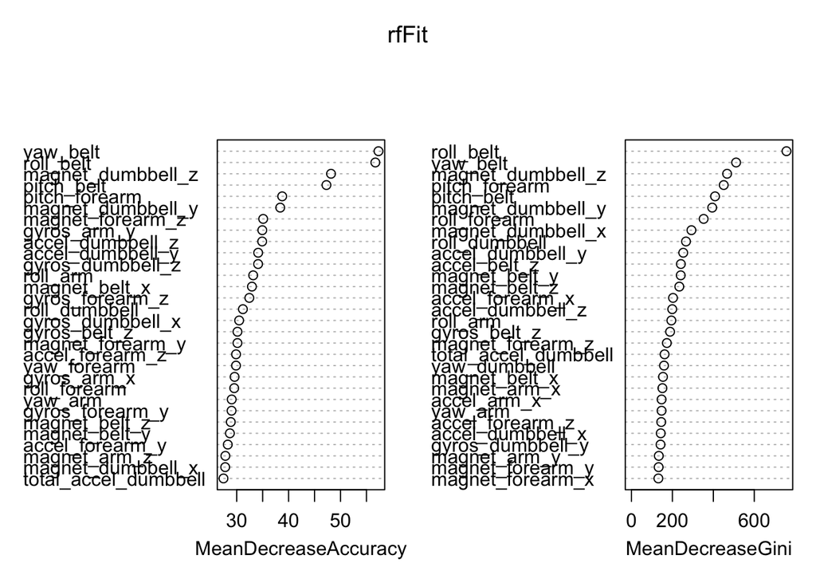

```r
varImpPlot(rfFit)
```

We can learn several things from this output. The graph above shows the relative importance of each variable in our data set. We can also see that the out-of-bag estimate of error rate is very low.

# Prediction Calculation

```r
prediction <- predict(rfFit, my_testing, type = "class")
confusionMatrix(prediction, my_testing$classe)
```

```
## Confusion Matrix and Statistics
##
##           Reference
## Prediction    A    B    C    D    E
##          A 2232    8    0    0    0
##          B    0 1507    4    0    0
##          C    0    3 1362   10    0
##          D    0    0    2 1275    3
##          E    0    0    0    1 1439
##
## Overall Statistics
##
##                Accuracy : 0.996
##                  95% CI : (0.994, 0.997)
##     No Information Rate : 0.284
##     P-Value [Acc > NIR] : <2e-16
##
##                   Kappa : 0.995
##  Mcnemar's Test P-Value : NA
##
## Statistics by Class:
##
##                      Class: A Class: B Class: C Class: D Class: E
## Sensitivity             1.000    0.993    0.996    0.991    0.998
## Specificity             0.999    0.999    0.998    0.999    1.000
## Pos Pred Value          0.996    0.997    0.991    0.996    0.999
## Neg Pred Value          1.000    0.998    0.999    0.998    1.000
## Prevalence              0.284    0.193    0.174    0.164    0.184
## Detection Rate          0.284    0.192    0.174    0.163    0.183
## Detection Prevalence    0.285    0.193    0.175    0.163    0.184
## Balanced Accuracy       0.999    0.996    0.997    0.995    0.999
```